# LAB 1: ANN and PyTorch [62 pts]

In this lab, you will start off by constructing a neural networks from scratch to get a stronger understanding of what is required to make neural networks work.

The first part of the lab involves building a neural network from scratch to gain a better understanding of how they work. The second part of the lab involves training a neural network using PyTorch to classify images as either "cat" or "dog". The code for the neural networks you train will be written for you, and you are not (yet!) expected to understand all provided code. However, by the end of the lab, you should be able to:

1. Understand at a high level the training loop for a machine learning model.
2. Understand the distinction between training, validation, and test data.
3. The concepts of overfitting and underfitting.
4. Investigate how different hyperparameters, such as learning rate and batch size, affect the success of training.
5. Compare an ANN (aka Multi-Layer Perceptron) with a CNN.

### What to submit

Submit an HTML file containing all your code, outputs, and write-up from parts A and B. You can produce a HTML file directly from Google Colab. The Colab instructions are provided at the end of this document.

**Do not submit any other files produced by your code.**

Include a link to your colab file in your submission.

Please use Google Colab to complete this assignment. If you want to use Jupyter Notebook, please complete the assignment and upload your Jupyter Notebook file to Google Colab for submission.

## Colab Link

Include a link to your colab file here

Colab Link:

# PART A: Constructing a Neural Network [15 pt]

Before we get into using PyTorch to train our classifier we will go through the process of creating our neural network from scratch. We've seen in the tutorial how to build a 1-layer network, now we'll take it one step further to build a 2-layer network. This is an important exercise that everyone should attempt at least once to understand and truly appreciate the workings of neural networks.

## Part A.0 Helper Functions

To help guide the construction we will use the iris dataset that was introduced in the tutorial. Provided are some helper code to get us started:

```python
# load "Iris_3class.csv" to Google Colab
from google.colab import files
uploaded = files.upload()
```

Upload widget is only available when the cell has been executed in the current browser session. Please rerun this cell to enable.

```
Saving Iris_3class.csv to Iris_3class.csv
```

```python
import pandas as pd
import numpy as np
import math
import matplotlib.pyplot as plt
```

```python
raw_data = pd.read_csv("Iris_3class.csv", header = None)
raw_data = raw_data.values
np.random.shuffle(raw_data)
```

```python
print(raw_data)

#order of columns

#sepal length in cm
#sepal width in cm
#petal length in cm
#petal width in cm
```

[output not shown]

```python
import numpy as np
#raw_data = raw_data.values()

# split your data into training and validation
X_train = raw_data[0:100,:4]
y_train = raw_data[0:100,4:5].astype(int)
X_val = raw_data[100:,:4]
y_val = raw_data[100:,4:5].astype(int)

print(X_train.shape, y_train.shape)
print(X_train.dtype, y_train.dtype)
print(X_val.shape, y_val.shape)
print(X_val.dtype, y_val.dtype)
```

```
(100, 4) (100, 1)
float64 int64
(50, 4) (50, 1)
float64 int64
```

Recall that the neural network output consists of several nodes, one for each output class. Since the labels are provided as integers we will need to convert them into one-hot vectors to match the neural network output format.

```python
#Convert array to one-hot encoding
def to_one_hot(Y):
    n_col = np.amax(Y) + 1
    binarized = np.zeros((len(Y), n_col))
    for i in range(len(Y)):
        binarized[i, Y[i]] = 1.
    return binarized
```

```python
y_train = to_one_hot(y_train)
print(X_train.shape, y_train.shape)
print(X_train.dtype, y_train.dtype)

y_val = to_one_hot(y_val)
print(X_val.shape, y_val.shape)
print(X_val.dtype, y_val.dtype)
```

```
(100, 4) (100, 3)
float64 float64
(50, 4) (50, 3)
float64 float64
```

```python
#verify one-hot encoding
y_train[0:10,:]
```

```
array([[0., 0., 1.],
       [1., 0., 0.],
       [0., 0., 1.],
       [0., 0., 1.],
       [0., 0., 1.],
       [1., 0., 0.],
       [0., 0., 1.],
       [1., 0., 0.],
       [0., 0., 1.],
       [1., 0., 0.]])
```

## Part A.1 Develop a 2-layer ANN [5 pt]

At its core a 2-layer neural network is just a few lines of code. Most of the complexity comes from setting up the training of the network.

Using vectorized form, set up the neural network training to use a cross-entropy loss function and determine the gradients with resepect to the layer 1 and layer 2 weights.

```python
# write code to create a 2-layer ANN in vectorized form

#define sigmoid
def sigmoid(x):
    return 1/(1+np.exp(-x))

#define softmax
def softmax(x):
  e = np.exp(x)
  return e/e.sum(axis=1, keepdims = True)


def ann(W, X_train, y_train):

  num_hidden = 5
  num_features = 4
  num_outputs = 3

  #Weights
  w0 = W[:20].reshape(num_features, num_hidden)
  w1 = W[20:].reshape(num_hidden, num_outputs)

  #Feed forward
  layer0 = X_train
  layer1 = sigmoid(np.dot(layer0, w0))
  layer2 = np.dot(layer1, w1)

  # softmax
  output = softmax(layer2)

  #Back propagation using gradient descent

  #cross-entropy loss
  error = np.sum(np.multiply(-y_train, np.log(output)))/len(X_train)

  #initialize gradients to zero
  dw0 = [0]
  dw1 = [0]

  #calculate gradients
  #dw1 = layer2 - y_train  # Not sure about this
  #dw0 = np.dot(dw1 , w1.T)* (layer1 , (1-layer1))

  # TO BE COMPLETED

  #determine gradients
  dw1 += (np.transpose(layer1))@(output-y_train)
  s1 = np.matmul((output-y_train) , np.transpose(w1))
  s2 = np.multiply(layer1,(1-layer1))
  s3 = np.multiply(s1,s2)
  dw0 += np.matmul(np.transpose(X_train), s3)


  #combine gradients into one vector
  dW = np.array(list(dw0.flatten())+list(dw1.flatten()))/len(X_train) # TO BE COMPLETED

  return (error, dW, output)
```

```python
num_hidden = 5
num_features = 4
num_outputs = 3

#initialize weights
w0 = 2*np.random.random((num_features, num_hidden)) - 1
w1 = 2*np.random.random((num_hidden, num_outputs)) - 1

#combine weights into a single vector
W = np.array(list(w0.flatten()) + list(w1.flatten()))

ann(W,X_train, y_train)
```

```
(1.186407386481382,
 array([ 0.04193736,  0.3613633 , -0.00128618, -0.17970938, -0.0569229 ,
         0.02404755,  0.15924009, -0.00181044, -0.08000074, -0.0413968 ,
         0.04084249,  0.31593776,  0.00155655, -0.16715005, -0.01237873,
         0.01990603,  0.11601435,  0.00077439, -0.06499307, -0.00108105,
         0.20082056, -0.08451309, -0.11630747,  0.1638241 , -0.05997567,
        -0.10384843,  0.29303853, -0.10626504, -0.1867735 ,  0.23047734,
        -0.07972317, -0.15075417, -0.0174564 ,  0.01224118,  0.00521522]),
 array([[0.6010547 , 0.23725193, 0.16169337],
        [0.69085609, 0.21787286, 0.09127106],
        [0.62127589, 0.24440659, 0.13431752],
        [0.61856367, 0.23882348, 0.14261285],
        [0.61104116, 0.2466251 , 0.14233374],
        [0.69397917, 0.21547307, 0.09054776],
        [0.59436814, 0.24479687, 0.16083499],
        [0.68448827, 0.22461796, 0.09089377],
        [0.59450695, 0.24683701, 0.15865603],
        [0.72087359, 0.19589342, 0.08323299],
        [0.61973749, 0.24990217, 0.13036035],
        [0.60676101, 0.23468517, 0.15855382],
        [0.68428604, 0.22168191, 0.09403205],
        [0.69967378, 0.21004867, 0.09027755],
        [0.62436521, 0.24802378, 0.12761101],
        [0.63468552, 0.24074269, 0.1245718 ],
        [0.67938412, 0.22860979, 0.09200609],
        [0.61272513, 0.23010916, 0.15716571],
        [0.6154611 , 0.24564243, 0.13889647],
        [0.61185106, 0.23806583, 0.15008311],
        [0.69437936, 0.21996427, 0.08565638],
        [0.62802978, 0.23267736, 0.13929286],
        [0.62511777, 0.2446125 , 0.13026972],
        [0.70276808, 0.21062966, 0.08660226],
        [0.63342122, 0.24033792, 0.12624087],
        [0.61872107, 0.2351264 , 0.14615253],
        [0.61599262, 0.23958464, 0.14442273],
        [0.6713911 , 0.23623685, 0.09237205],
        [0.60745975, 0.23543389, 0.15710636],
        [0.62296121, 0.25066179, 0.12637699],
        [0.62428931, 0.24853852, 0.12717216],
        [0.69568356, 0.21720437, 0.08711207],
```

[output cut: 53 more lines]

```
        [0.68294896, 0.22333918, 0.09371185],
        [0.60745975, 0.23543389, 0.15710636],
        [0.61955612, 0.25023372, 0.13021016],
        [0.68909565, 0.22208585, 0.0888185 ],
        [0.59862337, 0.24969539, 0.15168124],
        [0.69674585, 0.21739053, 0.08586362],
        [0.6240282 , 0.24845142, 0.12752038],
        [0.68891046, 0.22348423, 0.08760531],
        [0.6090333 , 0.24058372, 0.15038298],
        [0.70032084, 0.21239488, 0.08728428],
        [0.60464888, 0.24819925, 0.14715186],
        [0.69820794, 0.20908996, 0.09270211],
        [0.70233917, 0.20730453, 0.09035631],
        [0.61962678, 0.23589564, 0.14447758],
        [0.67848579, 0.23149222, 0.090022  ]]))
```

## Part A.2 Train your neural network. How well does your network work on the iris dataset? [5 pt]

Part A.2 of the lab assignment is focused on training the neural network that was created in Part 1. The code initializes the number of hidden units, features, and outputs. Then it initializes random weights for the two layers of the network, and combines them into a single vector W.

```python
num_hidden = 5
num_features = 4
num_outputs = 3

#initialize weights
w0 = 2*np.random.random((num_features, num_hidden)) - 1
w1 = 2*np.random.random((num_hidden, num_outputs)) - 1

#combine weights into a single vector
W = np.array(list(w0.flatten()) + list(w1.flatten()))

#train network
n = 0.001
iterations = 100000
errors = []
for i in range(iterations):
  (error, dW, y_pred) = ann(W, X_train, y_train)
  W += -dW * n
  errors.append(error)
```

```python
#examine ground truth training data
train = np.round(y_train, 0)
train[:5]
```

```
array([[0., 0., 1.],
       [1., 0., 0.],
       [0., 0., 1.],
       [0., 0., 1.],
       [0., 0., 1.]])
```

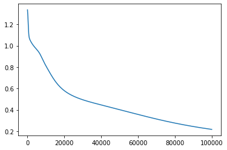

```python
np.round(y_pred , 1)
plt.plot(np.arange(len(errors)), np.array(errors))
```

## Part A.3 Validate that the gradients were computed correctly for the 2-layer neural network you developed. [5 pt]

Part A.3 is focused on validating the gradients computed for the 2-layer neural network. The code initializes random weights for the two layers of the network and combines them into a single vector W. It then computes the gradients analytically using the ann() function, and then computes the gradients numerically. The code does this by slightly incrementing the weights and computing the errors for each increment.

```python
#write code to numerical verify the gradients you calculated

num_hidden = 5
num_features = 4
num_outputs = 3

#initialize weights
w0 = 2*np.random.random((num_features, num_hidden)) - 1
w1 = 2*np.random.random((num_hidden, num_outputs)) - 1

#combine weights
W = np.array(list(w0.flatten()) + list(w1.flatten()))

#compute gradients analytically
(error, dW, y_pred) = ann(W, X_train, y_train)

#compute gradients numerically
dW_num = np.zeros((len(W),1))

for ind in range(len(W)):
  #reset gradients
  We1 = np.array(list(w0.flatten()) + list(w1.flatten()))
  We2 = np.array(list(w0.flatten()) + list(w1.flatten()))

  #increment slightly
  We1[ind] = We1[ind] + 0.0001
  We2[ind] = We2[ind]

  #compute errors
  (error_e1, dW_e1, y_pred1) = ann(We1, X_train, y_train)
  (error_e2, dW_e2, y_pred2) = ann(We2, X_train, y_train)

  #obtain numerical gradients
  grad_num = (error_e1 - error_e2)/0.0001

  #display difference between numerical and analytic gradients
  print(round(abs(grad_num - dW[ind]), 4), grad_num, dW[ind])
```

```
0.0 0.013979562789590005 0.013983252558269875
0.0 0.043214598766105894 0.04322347157970781
0.0 0.006322483347975805 0.006320969989003468
0.0 0.01704817885306298 0.017052191624735022
0.0 0.0620348162438944 0.06201464039653918
0.0 0.007508914612319728 0.0075099952552997494
0.0 0.029057202142190874 0.029061209845419076
0.0 0.0044041812730100105 0.004403443819930596
0.0 0.008648669154176503 0.008649753722608828
0.0 0.05508618045935165 0.055075763575716724
0.0 0.007491395885850238 0.007492596745472712
0.0 0.013863647054801476 0.01386464595876869
0.0 0.0017069493774002353 0.001706864234062355
0.0 0.006714778710836811 0.00671474847171734
0.0 -0.01569789563893309 -0.01569582646642556
0.0 0.0019399683659493405 0.0019400479835229906
0.0 0.00249252956940893 0.0024925606717140863
0.0 0.0002337308346866962 0.00023373210425605144
0.0 0.0003672661064157978 0.000367018862225756
0.0 -0.013526224336146697 -0.01352561376098699
0.0 -0.1727318469302297 -0.17273879286617114
0.0 -0.17237302739614435 -0.17237971152725945
0.0 0.345129360259655 0.34511850439343045
0.0 -0.1516920808741773 -0.1516986207613671
0.0 -0.17504832356962652 -0.17505463721531522
0.0 0.32676350065763415 0.3267532579766823
0.0 -0.0026504273709093695 -0.002650427631218745
0.0 0.0003831440920087914 0.0003831438526359013
0.0 0.002267284178181228 0.0022672837785828446
0.0 -0.18432253563016587 -0.18432893673705344
0.0 -0.16313252123145716 -0.16313865489360516
0.0 0.34747757022834946 0.34746759163065877
0.0 -0.0024352320782128345 -0.0024355108073590287
0.0 -0.04710443724187385 -0.04710471461119331
0.0 0.04954067053475342 0.04954022541855234
```

# PART B: Cats vs Dogs [47 pt]

In Part B of the lab, we will use PyTorch to train a neural network to identify cats and Dogs. The code starts by importing some libraries, including numpy, torch, and torchvision. This section provides some helper functions for loading and preprocessing the data.

```python
import numpy as np
import time
import torch
import torch.nn as nn
import torch.nn.functional as F
import torch.optim as optim
import torchvision
from torch.utils.data.sampler import SubsetRandomSampler
import torchvision.transforms as transforms
```

## Part B.0 Helper Functions

We will be making use of the following helper functions. You will be asked to look at and possibly modify some of these, but you are not expected to understand all of them.

You should look at the function names and read the docstrings. If you are curious, come back and explore the code *after* making some progress on the lab.

```python
###############################################################################
# Data Loading

def get_relevant_indices(dataset, classes, target_classes):
    """ Return the indices for datapoints in the dataset that belongs to the
    desired target classes, a subset of all possible classes.

    Args:
        dataset: Dataset object
        classes: A list of strings denoting the name of each class
        target_classes: A list of strings denoting the name of desired classes
                        Should be a subset of the 'classes'
    Returns:
        indices: list of indices that have labels corresponding to one of the
                 target classes
    """
    indices = []
    for i in range(len(dataset)):
        # Check if the label is in the target classes
        label_index = dataset[i][1] # ex: 9
        label_class = classes[label_index] # ex: 'truck'
        if label_class in target_classes:
            indices.append(i)
    return indices

def get_data_loader(target_classes, batch_size):
    """ Loads images of cat and dogs, splits the data into training, validation
    and testing datasets. Returns data loaders for the three preprocessed datasets.

    Args:
        target_classes: A list of strings denoting the name of the desired
                        classes. Should be a subset of the argument 'classes'
        batch_size: A int representing the number of samples per batch

    Returns:
        train_loader: iterable training dataset organized according to batch size
        val_loader: iterable validation dataset organized according to batch size
        test_loader: iterable testing dataset organized according to batch size
        classes: A list of strings denoting the name of each class
    """

    classes = ('plane', 'car', 'bird', 'cat',
               'deer', 'dog', 'frog', 'horse', 'ship', 'truck')
    ########################################################################
    # The output of torchvision datasets are PILImage images of range [0, 1].
    # We transform them to Tensors of normalized range [-1, 1].
    transform = transforms.Compose(
        [transforms.ToTensor(),
         transforms.Normalize((0.5, 0.5, 0.5), (0.5, 0.5, 0.5))])
    # Load CIFAR10 training data
    trainset = torchvision.datasets.CIFAR10(root='./data', train=True,
                                            download=True, transform=transform)
    # Get the list of indices to sample from
    relevant_indices = get_relevant_indices(trainset, classes, target_classes)

    # Split into train and validation
    np.random.seed(1000) # Fixed numpy random seed for reproducible shuffling
    np.random.shuffle(relevant_indices)
    split = int(len(relevant_indices) * 0.8) #split at 80%

    # split into training and validation indices
    relevant_train_indices, relevant_val_indices = relevant_indices[:split], relevant_indices[split:]
    train_sampler = SubsetRandomSampler(relevant_train_indices)
    train_loader = torch.utils.data.DataLoader(trainset, batch_size=batch_size,
                                               num_workers=1, sampler=train_sampler)
    val_sampler = SubsetRandomSampler(relevant_val_indices)
    val_loader = torch.utils.data.DataLoader(trainset, batch_size=batch_size,
                                              num_workers=1, sampler=val_sampler)
    # Load CIFAR10 testing data
    testset = torchvision.datasets.CIFAR10(root='./data', train=False,
                                           download=True, transform=transform)
    # Get the list of indices to sample from
    relevant_test_indices = get_relevant_indices(testset, classes, target_classes)
    test_sampler = SubsetRandomSampler(relevant_test_indices)
    test_loader = torch.utils.data.DataLoader(testset, batch_size=batch_size,
                                             num_workers=1, sampler=test_sampler)
    return train_loader, val_loader, test_loader, classes

###############################################################################
# Training
def get_model_name(name, batch_size, learning_rate, epoch):
    """ Generate a name for the model consisting of all the hyperparameter values

    Args:
        config: Configuration object containing the hyperparameters
    Returns:
        path: A string with the hyperparameter name and value concatenated
    """
    path = "model_{0}_bs{1}_lr{2}_epoch{3}".format(name,
                                                   batch_size,
                                                   learning_rate,
                                                   epoch)
    return path

def normalize_label(labels):
    """
    Given a tensor containing 2 possible values, normalize this to 0/1

    Args:
        labels: a 1D tensor containing two possible scalar values
    Returns:
        A tensor normalize to 0/1 value
    """
    max_val = torch.max(labels)
    min_val = torch.min(labels)
    norm_labels = (labels - min_val)/(max_val - min_val)
    return norm_labels

def evaluate(net, loader, criterion):
    """ Evaluate the network on the validation set.

     Args:
         net: PyTorch neural network object
         loader: PyTorch data loader for the validation set
         criterion: The loss function
     Returns:
         err: A scalar for the avg classification error over the validation set
         loss: A scalar for the average loss function over the validation set
     """
    total_loss = 0.0
    total_err = 0.0
    total_epoch = 0
    for i, data in enumerate(loader, 0):
        inputs, labels = data
        labels = normalize_label(labels)  # Convert labels to 0/1
        outputs = net(inputs)
        loss = criterion(outputs, labels.float())
        corr = (outputs > 0.0).squeeze().long() != labels
        total_err += int(corr.sum())
        total_loss += loss.item()
        total_epoch += len(labels)
    err = float(total_err) / total_epoch
    loss = float(total_loss) / (i + 1)
    return err, loss

###############################################################################
# Training Curve
def plot_training_curve(path):
    """ Plots the training curve for a model run, given the csv files
    containing the train/validation error/loss.

    Args:
        path: The base path of the csv files produced during training
    """
    import matplotlib.pyplot as plt
    train_err = np.loadtxt("{}_train_err.csv".format(path))
    val_err = np.loadtxt("{}_val_err.csv".format(path))
    train_loss = np.loadtxt("{}_train_loss.csv".format(path))
    val_loss = np.loadtxt("{}_val_loss.csv".format(path))
    plt.title("Train vs Validation Error")
    n = len(train_err) # number of epochs
    plt.plot(range(1,n+1), train_err, label="Train")
    plt.plot(range(1,n+1), val_err, label="Validation")
    plt.xlabel("Epoch")
    plt.ylabel("Error")
    plt.legend(loc='best')
    plt.show()
    plt.title("Train vs Validation Loss")
    plt.plot(range(1,n+1), train_loss, label="Train")
    plt.plot(range(1,n+1), val_loss, label="Validation")
    plt.xlabel("Epoch")
    plt.ylabel("Loss")
    plt.legend(loc='best')
    plt.show()
```

## Part B.1 Visualizing the Data [5 pt]

We will make use of some of the CIFAR-10 data set, which consists of colour images of size 32x32 pixels belonging to 10 categories. You can find out more about the dataset at https://www.cs.toronto.edu/~kriz/cifar.html

For this assignment, we will only be using the cat and dog categories. We have included code that automatically downloads the dataset the first time that the main script is run.

```python
# This will download the CIFAR-10 dataset to a folder called "data"
# the first time you run this code.
train_loader, val_loader, test_loader, classes = get_data_loader(
    target_classes=["cat", "dog"],
    batch_size=1) # One image per batch
```

```
Downloading https://www.cs.toronto.edu/~kriz/cifar-10-python.tar.gz to ./data/cifar-10-python.tar.gz
```

```
Extracting ./data/cifar-10-python.tar.gz to ./data
Files already downloaded and verified
```

### Part B.1.a - [1 pt]

Visualize some of the data by running the code below. Include the visualization in your writeup.

Your figures should show up directly in the jupyter notebook.

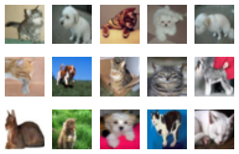

```python
import matplotlib.pyplot as plt

k = 0
for images, labels in train_loader:
    # since batch_size = 1, there is only 1 image in `images`
    image = images[0]
    # place the colour channel at the end, instead of at the beginning
    img = np.transpose(image, [1,2,0])
    # normalize pixel intensity values to [0, 1]
    img = img / 2 + 0.5
    plt.subplot(3, 5, k+1)
    plt.axis('off')
    plt.imshow(img)

    k += 1
    if k > 14:
        break
```

### Part B.1.b - [2 pt]

How many training examples do we have for the combined `cat` and `dog` classes? What about validation examples? What about test examples?

```python
print("Number of training examples is:",len(train_loader))
print("Number of validation examples is:",len(val_loader))
print("Number of test examples is:",len(test_loader))
```

```
Number of training examples is: 8000
Number of validation examples is: 2000
Number of test examples is: 2000
```

### Part B.1.c - [2pt]

Why do we need a validation set when training our model? What happens if we judge the performance of our models using the training set loss/error instead of the validation set loss/error?

```python
# We need a validation model to tune the hyperparameters and make sure that
# our model is not overfitting the training data. If model performance
# would have been assessed based on training loss and error, then we would
# overfit the data to make sure to minimize the training loss and error.
# this would in fact lead the model to memorize the set of datapoints and not
# learn the dataset
```

## Part B.2 Training [10 pt]

We define two neural networks, a `LargeNet` and `SmallNet`. We'll be training the networks in this section.

You won't understand fully what these networks are doing until the next few classes, and that's okay. For this assignment, please focus on learning how to train networks, and how hyperparameters affect training.

```python
class LargeNet(nn.Module):
    def __init__(self):
        super(LargeNet, self).__init__()
        self.name = "large"
        self.conv1 = nn.Conv2d(3, 5, 5)
        self.pool = nn.MaxPool2d(2, 2)
        self.conv2 = nn.Conv2d(5, 10, 5)
        self.fc1 = nn.Linear(10 * 5 * 5, 32)
        self.fc2 = nn.Linear(32, 1)

    def forward(self, x):
        x = self.pool(F.relu(self.conv1(x)))
        x = self.pool(F.relu(self.conv2(x)))
        x = x.view(-1, 10 * 5 * 5)
        x = F.relu(self.fc1(x))
        x = self.fc2(x)
        x = x.squeeze(1) # Flatten to [batch_size]
        return x
```

```python
class SmallNet(nn.Module):
    def __init__(self):
        super(SmallNet, self).__init__()
        self.name = "small"
        self.conv = nn.Conv2d(3, 5, 3)
        self.pool = nn.MaxPool2d(2, 2)
        self.fc = nn.Linear(5 * 7 * 7, 1)

    def forward(self, x):
        x = self.pool(F.relu(self.conv(x)))
        x = self.pool(x)
        x = x.view(-1, 5 * 7 * 7)
        x = self.fc(x)
        x = x.squeeze(1) # Flatten to [batch_size]
        return x
```

```python
small_net = SmallNet()
large_net = LargeNet()
```

### Part B.2.a - [1pt]

The methods `small_net.parameters()` and `large_net.parameters()` produces an iterator of all the trainable parameters of the network. These parameters are torch tensors containing many scalar values.

We haven't learned how how the parameters in these high-dimensional tensors will be used, but we should be able to count the number of parameters. Measuring the number of parameters in a network is one way of measuring the "size" of a network.

What is the total number of parameters in `small_net` and in `large_net`? (Hint: how many numbers are in each tensor?)

```python
for param in small_net.parameters():
    print(param.shape)

print("\n")

for param in large_net.parameters():
  print(param.shape)


print("\nNumber of parameters for small_net is:",sum(p.numel() for p in small_net.parameters() if p.requires_grad))
print("Number of parameters for large_net is:", sum(p.numel() for p in large_net.parameters() if p.requires_grad))
```

```
torch.Size([5, 3, 3, 3])
torch.Size([5])
torch.Size([1, 245])
torch.Size([1])


torch.Size([5, 3, 5, 5])
torch.Size([5])
torch.Size([10, 5, 5, 5])
torch.Size([10])
torch.Size([32, 250])
torch.Size([32])
torch.Size([1, 32])
torch.Size([1])

Number of parameters for small_net is: 386
Number of parameters for large_net is: 9705
```

### The function train_net

The function `train_net` below takes an untrained neural network (like `small_net` and `large_net`) and several other parameters. You should be able to understand how this function works. The figure below shows the high level training loop for a machine learning model:

[figure not shown]

```python
def train_net(net, batch_size=64, learning_rate=0.01, num_epochs=30):
    ########################################################################
    # Train a classifier on cats and dogs
    target_classes = ["cat", "dog"]
    ########################################################################
    # Fixed PyTorch random seed for reproducible result
    torch.manual_seed(1000)
    ########################################################################
    # Obtain the PyTorch data loader objects to load batches of the datasets
    train_loader, val_loader, test_loader, classes = get_data_loader(
            target_classes, batch_size)
    ########################################################################
    # Define the Loss function and optimizer
    # The loss function will be Binary Cross Entropy (BCE). In this case we
    # will use the BCEWithLogitsLoss which takes unnormalized output from
    # the neural network and scalar label.
    # Optimizer will be SGD with Momentum.
    criterion = nn.BCEWithLogitsLoss()
    optimizer = optim.SGD(net.parameters(), lr=learning_rate, momentum=0.9)
    ########################################################################
    # Set up some numpy arrays to store the training/test loss/erruracy
    train_err = np.zeros(num_epochs)
    train_loss = np.zeros(num_epochs)
    val_err = np.zeros(num_epochs)
    val_loss = np.zeros(num_epochs)
    ########################################################################
    # Train the network
    # Loop over the data iterator and sample a new batch of training data
    # Get the output from the network, and optimize our loss function.
    start_time = time.time()
    for epoch in range(num_epochs):  # loop over the dataset multiple times
        total_train_loss = 0.0
        total_train_err = 0.0
        total_epoch = 0
        for i, data in enumerate(train_loader, 0):
            # Get the inputs
            inputs, labels = data
            labels = normalize_label(labels) # Convert labels to 0/1
            # Zero the parameter gradients
            optimizer.zero_grad()
            # Forward pass, backward pass, and optimize
            outputs = net(inputs)
            loss = criterion(outputs, labels.float())
            loss.backward()
            optimizer.step()
            # Calculate the statistics
            corr = (outputs > 0.0).squeeze().long() != labels
            total_train_err += int(corr.sum())
            total_train_loss += loss.item()
            total_epoch += len(labels)
        train_err[epoch] = float(total_train_err) / total_epoch
        train_loss[epoch] = float(total_train_loss) / (i+1)
        val_err[epoch], val_loss[epoch] = evaluate(net, val_loader, criterion)
        print(("Epoch {}: Train err: {}, Train loss: {} |"+
               "Validation err: {}, Validation loss: {}").format(
                   epoch + 1,
                   train_err[epoch],
                   train_loss[epoch],
                   val_err[epoch],
                   val_loss[epoch]))
        # Save the current model (checkpoint) to a file
        model_path = get_model_name(net.name, batch_size, learning_rate, epoch)
        torch.save(net.state_dict(), model_path)
    print('Finished Training')
    end_time = time.time()
    elapsed_time = end_time - start_time
    print("Total time elapsed: {:.2f} seconds".format(elapsed_time))
    # Write the train/test loss/err into CSV file for plotting later
    epochs = np.arange(1, num_epochs + 1)
    np.savetxt("{}_train_err.csv".format(model_path), train_err)
    np.savetxt("{}_train_loss.csv".format(model_path), train_loss)
    np.savetxt("{}_val_err.csv".format(model_path), val_err)
    np.savetxt("{}_val_loss.csv".format(model_path), val_loss)
```

### Part B.2.b - [1pt]

The parameters to the function `train_net` are hyperparameters of our neural network. We made these hyperparameters easy to modify so that we can tune them later on.

What are the default values of the parameters `batch_size`, `learning_rate`, and `num_epochs`?

```python
#batch_size= 64
#learning_rate= 0.01
#num_epochs= 30
```

### Part B.2.c - [1 pt]

What files stored in memory when we call `train_net` with `small_net`, and train for 5 epochs? Provide a list of all the files written to disk, and what information the files contain.

```python
train_net(small_net,batch_size=64,learning_rate=0.001,num_epochs=5)
```

```
Files already downloaded and verified
Files already downloaded and verified
Epoch 1: Train err: 0.489, Train loss: 0.6922892999649047 |Validation err: 0.446, Validation loss: 0.6873974017798901
Epoch 2: Train err: 0.435625, Train loss: 0.6823928594589234 |Validation err: 0.4005, Validation loss: 0.6799632832407951
Epoch 3: Train err: 0.40475, Train loss: 0.6742710480690003 |Validation err: 0.3935, Validation loss: 0.6717468108981848
Epoch 4: Train err: 0.395, Train loss: 0.6669722380638122 |Validation err: 0.3875, Validation loss: 0.6637394651770592
Epoch 5: Train err: 0.383125, Train loss: 0.6606107974052429 |Validation err: 0.3865, Validation loss: 0.6614711359143257
Finished Training
Total time elapsed: 20.02 seconds
```

```python
#The files written to disk are training checkpoints with epochs , along with training and validation error and loss all
# written to an csv file.


# model_small_bs64_lr0.001 for the 5 epochs sving the weights for every  epoch
# Data included in this file is the training error, training loss, validation error and validation loss.
```

### Part B.2.d - [2pt]

Train both `small_net` and `large_net` using the function `train_net` and its default parameters. The function will write many files to disk, including a model checkpoint (saved values of model weights) at the end of each epoch.

If you are using Google Colab, you will need to mount Google Drive so that the files generated by `train_net` gets saved. We will be using these files in part (d). (See the Google Colab tutorial for more information about this.)

Report the total time elapsed when training each network. Which network took longer to train? Why?

```python
# Since the function writes files to disk, you will need to mount
# your Google Drive. If you are working on the lab locally, you
# can comment out this code.

from google.colab import drive
drive.mount('/content/gdrive')
```

```python
# Runnin time for the following train_net arguments (batch_size=64, learning_rate=0.01, num_epochs=30)
  # - Small_Net = 117.81 seconds
  # - Large_Net = 127.41 seconds

# Large_Net took longer to run becasue of the higher number of layers and threrefore the increase necessity of training and
# leanring paramters
```

```python
train_net(small_net,batch_size=64, learning_rate=0.01, num_epochs=30)
```

```
Files already downloaded and verified
Files already downloaded and verified
Epoch 1: Train err: 0.37425, Train loss: 0.6462789568901062 |Validation err: 0.3575, Validation loss: 0.64184738881886
Epoch 2: Train err: 0.34275, Train loss: 0.6240558958053589 |Validation err: 0.3525, Validation loss: 0.6338145453482866
Epoch 3: Train err: 0.334, Train loss: 0.614204960346222 |Validation err: 0.3435, Validation loss: 0.6220561284571886
Epoch 4: Train err: 0.3275, Train loss: 0.6060741055011749 |Validation err: 0.371, Validation loss: 0.6313801072537899
Epoch 5: Train err: 0.31825, Train loss: 0.5961392443180085 |Validation err: 0.331, Validation loss: 0.6156866252422333
Epoch 6: Train err: 0.31575, Train loss: 0.5888265507221222 |Validation err: 0.343, Validation loss: 0.6203637784346938
Epoch 7: Train err: 0.312375, Train loss: 0.5876604332923889 |Validation err: 0.3365, Validation loss: 0.6055785492062569
Epoch 8: Train err: 0.30425, Train loss: 0.5804806346893311 |Validation err: 0.3135, Validation loss: 0.6001750640571117
Epoch 9: Train err: 0.303625, Train loss: 0.5802746534347534 |Validation err: 0.316, Validation loss: 0.598428662866354
Epoch 10: Train err: 0.30025, Train loss: 0.5777591297626495 |Validation err: 0.321, Validation loss: 0.5960888601839542
Epoch 11: Train err: 0.3, Train loss: 0.5756001145839691 |Validation err: 0.324, Validation loss: 0.6035746801644564
Epoch 12: Train err: 0.295625, Train loss: 0.5696788041591644 |Validation err: 0.337, Validation loss: 0.6123691191896796
Epoch 13: Train err: 0.298125, Train loss: 0.5711746966838837 |Validation err: 0.313, Validation loss: 0.5991412680596113
Epoch 14: Train err: 0.29475, Train loss: 0.56570796084404 |Validation err: 0.3295, Validation loss: 0.6152008818462491
Epoch 15: Train err: 0.291, Train loss: 0.5664627892971039 |Validation err: 0.311, Validation loss: 0.5942691899836063
Epoch 16: Train err: 0.29625, Train loss: 0.569672466993332 |Validation err: 0.309, Validation loss: 0.6044116262346506
Epoch 17: Train err: 0.2915, Train loss: 0.5635679512023926 |Validation err: 0.3105, Validation loss: 0.5947589045390487
Epoch 18: Train err: 0.290375, Train loss: 0.5590768005847931 |Validation err: 0.3125, Validation loss: 0.5949988849461079
Epoch 19: Train err: 0.284, Train loss: 0.5570300860404969 |Validation err: 0.3205, Validation loss: 0.6029104124754667
Epoch 20: Train err: 0.28, Train loss: 0.5554271574020386 |Validation err: 0.3175, Validation loss: 0.6042693881317973
Epoch 21: Train err: 0.285875, Train loss: 0.5571381196975708 |Validation err: 0.3125, Validation loss: 0.5870802663266659
Epoch 22: Train err: 0.28325, Train loss: 0.5549676082134247 |Validation err: 0.319, Validation loss: 0.5978359719738364
Epoch 23: Train err: 0.282625, Train loss: 0.5530444698333741 |Validation err: 0.311, Validation loss: 0.5890923533588648
Epoch 24: Train err: 0.281625, Train loss: 0.5528891944885254 |Validation err: 0.3135, Validation loss: 0.598714024759829
Epoch 25: Train err: 0.27725, Train loss: 0.5500040910243988 |Validation err: 0.3125, Validation loss: 0.5857355995103717
Epoch 26: Train err: 0.279625, Train loss: 0.5480553135871887 |Validation err: 0.3065, Validation loss: 0.5896659614518285
Epoch 27: Train err: 0.277375, Train loss: 0.5484699306488037 |Validation err: 0.315, Validation loss: 0.6029238626360893
Epoch 28: Train err: 0.27825, Train loss: 0.5468852124214172 |Validation err: 0.3055, Validation loss: 0.5867233844473958
Epoch 29: Train err: 0.274125, Train loss: 0.5474272549152375 |Validation err: 0.3115, Validation loss: 0.5934409443289042
Epoch 30: Train err: 0.280875, Train loss: 0.5474958755970001 |Validation err: 0.3165, Validation loss: 0.5919168014079332
Finished Training
Total time elapsed: 117.81 seconds
```

```python
train_net(large_net,batch_size=64, learning_rate=0.01, num_epochs=30)
```

```
Files already downloaded and verified
Files already downloaded and verified
Epoch 1: Train err: 0.4915, Train loss: 0.692859510421753 |Validation err: 0.426, Validation loss: 0.6910435128957033
Epoch 2: Train err: 0.444125, Train loss: 0.6873988251686096 |Validation err: 0.4105, Validation loss: 0.6791014224290848
Epoch 3: Train err: 0.421625, Train loss: 0.6751894202232361 |Validation err: 0.3955, Validation loss: 0.6607093662023544
Epoch 4: Train err: 0.38025, Train loss: 0.6540400228500366 |Validation err: 0.374, Validation loss: 0.6479317806661129
Epoch 5: Train err: 0.355875, Train loss: 0.636110424041748 |Validation err: 0.3485, Validation loss: 0.6300408188253641
Epoch 6: Train err: 0.339, Train loss: 0.6178345682621003 |Validation err: 0.338, Validation loss: 0.61744081415236
Epoch 7: Train err: 0.32825, Train loss: 0.6053278603553772 |Validation err: 0.3335, Validation loss: 0.6155488938093185
Epoch 8: Train err: 0.31975, Train loss: 0.5914061706066132 |Validation err: 0.324, Validation loss: 0.6028522681444883
Epoch 9: Train err: 0.309125, Train loss: 0.5833906564712524 |Validation err: 0.3275, Validation loss: 0.6034618653357029
Epoch 10: Train err: 0.302875, Train loss: 0.5712606189250946 |Validation err: 0.3045, Validation loss: 0.5891367485746741
Epoch 11: Train err: 0.291375, Train loss: 0.5625741713047028 |Validation err: 0.3145, Validation loss: 0.5962669514119625
Epoch 12: Train err: 0.286875, Train loss: 0.5495517683029175 |Validation err: 0.3005, Validation loss: 0.5900937113910913
Epoch 13: Train err: 0.2775, Train loss: 0.5407464747428894 |Validation err: 0.2975, Validation loss: 0.5914809769019485
Epoch 14: Train err: 0.271375, Train loss: 0.5316061241626739 |Validation err: 0.308, Validation loss: 0.5877022482454777
Epoch 15: Train err: 0.263, Train loss: 0.523601359128952 |Validation err: 0.3, Validation loss: 0.5872044051066041
Epoch 16: Train err: 0.262875, Train loss: 0.5212172157764435 |Validation err: 0.304, Validation loss: 0.5816676486283541
Epoch 17: Train err: 0.259375, Train loss: 0.5171811819076538 |Validation err: 0.295, Validation loss: 0.5777007797732949
Epoch 18: Train err: 0.247, Train loss: 0.4938573670387268 |Validation err: 0.3095, Validation loss: 0.5773925334215164
Epoch 19: Train err: 0.237, Train loss: 0.4845016839504242 |Validation err: 0.3015, Validation loss: 0.5891419323161244
Epoch 20: Train err: 0.230375, Train loss: 0.4756387164592743 |Validation err: 0.307, Validation loss: 0.604935310781002
Epoch 21: Train err: 0.225375, Train loss: 0.46792867803573607 |Validation err: 0.2875, Validation loss: 0.5708998320624232
Epoch 22: Train err: 0.215375, Train loss: 0.45118590927124025 |Validation err: 0.281, Validation loss: 0.5831090221181512
Epoch 23: Train err: 0.214375, Train loss: 0.44773014187812804 |Validation err: 0.2865, Validation loss: 0.5820968728512526
Epoch 24: Train err: 0.199375, Train loss: 0.4221770920753479 |Validation err: 0.3, Validation loss: 0.6404200177639723
Epoch 25: Train err: 0.19475, Train loss: 0.4122986934185028 |Validation err: 0.2935, Validation loss: 0.595723363570869
Epoch 26: Train err: 0.186875, Train loss: 0.4013508439064026 |Validation err: 0.2965, Validation loss: 0.6334431460127234
Epoch 27: Train err: 0.177625, Train loss: 0.38551045417785645 |Validation err: 0.298, Validation loss: 0.6341783525422215
Epoch 28: Train err: 0.17475, Train loss: 0.37766574943065645 |Validation err: 0.3, Validation loss: 0.644133348017931
Epoch 29: Train err: 0.16575, Train loss: 0.36666291880607604 |Validation err: 0.295, Validation loss: 0.7127099400386214
Epoch 30: Train err: 0.157125, Train loss: 0.3503166525363922 |Validation err: 0.3015, Validation loss: 0.6441395841538906
Finished Training
Total time elapsed: 127.41 seconds
```